# Item Fit

WHO Technical Training

Carolina Fellinghauer

fellinghauerc@who.int

April 2021

# Getting ready

```r
# install or load following R-packages
library(eRm)
library(iarm)
```

and load the Stress Related Growth data (SRG) :

```r
# get the SRG dataset from GitHub

urlfile <- "https://raw.githubusercontent.com/CarolinaFellinghauer/WHO_Training_Rasch/main/Data/SRG_Data_Course_UZH_HS2021.csv"

srg.data <- read.csv(url(urlfile))


dim(srg.data)
```

```
[1] 450  26
```

```r
colnames(srg.data)
```

```
 [1] "X"                      "ID"                     "Age"
 [4] "Gender"                 "Completeness"           "para.tetra_1"
 [7] "traumatic_nontraumatic" "PersStat"               "SRG1"
[10] "SRG2"                   "SRG3"                   "SRG4"
[13] "SRG5"                   "SRG6"                   "SRG7"
[16] "SRG8"                   "SRG9"                   "SRG10"
[19] "SRG11"                  "SRG12"                  "SRG13"
[22] "SRG14"                  "SRG15"                  "TP"
[25] "ID_Unik"                "wgt"
```

```r
srg.items <- c("SRG1", "SRG2", "SRG3", "SRG4", "SRG5", "SRG6", "SRG7", "SRG8", "SRG9",
    "SRG10", "SRG11", "SRG12", "SRG13", "SRG14", "SRG15")


# dataset with only the SRG items
data.srg <- srg.data[, srg.items]

# check response coding (frequencies including missing values) for each SRG-item
apply(data.srg, 2, table, useNA = "always")
```

```
     SRG1 SRG2 SRG3 SRG4 SRG5 SRG6 SRG7 SRG8 SRG9 SRG10 SRG11 SRG12 SRG13 SRG14
0     170  286  125  153  122  178  159  223  148    88   174   258    43   135
1     218  128  188  180  154  162  203  153  207   225   159   129   216   192
2      60   34  132  115  172  110   85   74   95   135   117    58   191   123
<NA>    2    2    5    2    2    0    3    0    0     2     0     5     0     0
     SRG15
0       57
1      135
2      257
<NA>     1
```

# Item Fit

Item fit statistics are commonly reported in validation studies with the Rasch model, as they indicate how well items describe the continuum of a latent trait. The item fit shows how accurately or predictably data fit the Rasch model. Several approaches to test if an item fits the scale exist, one commonly used statistic being the infit and outfit mean squares.

## Infit and Outfit

Infit and outfit are mean-square residual summary statistics that range from zero to infinity. Good fit of an item can be expected when these statistics are close or equal to 1.

To find the item fit requires:

1. to calculate the **expected response for each observation** $X_{ij}$, i.e. the response for item $i$ and person $j$ based on the estimated person and item parameter.

$$E_{ij} = \Sigma^{mi}_{k=0} k (P_{ikj})$$

$P_{ikj}$ is the probability of a person $j$ responding $k$ on item $i$. The letter $k$ stands for the response categories starting from 0, e.g. 0 and 1 for a dichotomous data collection.

2. to calculate a **score residual** $Y_{ij}$:

$$Y_{ij} = X_{ij} - E_{ij}$$
and a **standardized residual** $Z_{ij}$:

$$Z_{ij} = \frac{Y_{ij}}{(W_{ij})^{1/2}}$$

where $W_{ij} = \Sigma^{mi}_{k=0}(k-E_{ij})^2 P_{ikj}$ is the variance of $X_{ij}$.

3. The standardized residuals are squared and summed to form a **Chi-square statistic**:

$$\chi^2 = \Sigma^N_{n=1}Z_{ij}^2$$

4. The chi-square statistic divided by N corresponds to the **Mean-Square Outfit statistic**

$$Outfit_i = \frac{\Sigma^N_{n=1}Z_{ij}^2}{N}$$

The outfit statistic is sensitive to outlier, i.e. off-target information.

5. to diminish this effect of the Outfit statistic, the **Mean-Square Infit** adjusts the squared standardized residuals $Z_{ij}^2$, by their individual variances, $W_{ij}$:

$$Infit_{i} = \frac{\Sigma^N_{n=1}W_{ij}Z_{ij}^2}{\Sigma^N_{n=1}W_{ij}}$$
The variance $W_{ij}$ is found above, the same for standardizing the residuals.

```r
# Example : outfit and infit equation in R for the dichotomous case
library(eRm)

# a simulated sample
data.test <- eRm::sim.rasch(500, 10, seed = 1234)

# running the Rasch model
RM.test <- RM(data.test)

# extracting the person.parameter these are required to extract residuals,
# probabilities, and fit statistics
PP <- person.parameter(RM.test)

# getting the residuals
Zij <- residuals(PP)

# residuals squared for the equation
Zij_square <- Zij^2

# Outfit
Outfit <- colSums(Zij_square)/nrow(Zij)  #diy outfit
Outfit2 <- itemfit(PP)$i.outfitMSQ  #outfit from package

# compare
cbind(Outfit, Outfit2)

####################################################################

# infit requires computing the variance Wij

# the response probabilities
Probs <- pmat(PP)
# Expected response
Eij <- Probs * 1 + (1 - Probs) * 0

# Variance
Wij <- (1 - Eij)^2 * Probs + (0 - Eij)^2 * (1 - Probs)

# Infit
Infit <- colSums(Wij * Zij_square)/colSums(Wij)  #diy infit
Infit2 <- itemfit(PP)$i.infitMSQ  #infit from package

# compare
cbind(Infit, Infit2)
```

## Underfit and Overfit

Under the null hypothesis, the expected value of the Infit and Outfit statistic of a fitting item is equal to one. Values much greater than one (> 1.3 for example) indicate **underdiscrimination** while values below one (< 0.7 for example) **overdiscrimination**.

**Underdiscriminating** items do not allow to differentiate person on a cut-off, the information is ‘blurred’. The sample cannot be stratified or measured with underdiscriminating items.

**Overdiscriminating** items are too ‘sharp’ and do not add any information about relative performances to the scale. Overdiscriminating items act like an on/off switch but not like a measuring device.

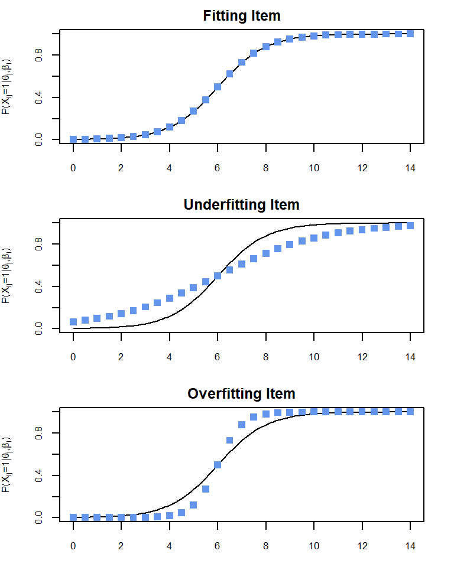

In general, underdiscriminating items are more a problem for a measurement scale than overdiscriminating items.

*T*-statistic and *P*-values can be derived for the infit and outfit statistics to determine how significantly an item’s fit statistic is departing from what would be expected. For more details see (Smith, Schumacker, and Bush 1998).

# Diagnostics

## Numeric Output Analysis

To calculate the item fit with `eRm` requires the `itemfit()` function which uses the output of the `person.parameter` object.

```r
# starting with the PCM analysis
PCM.srg <- PCM(data.srg)


# first apply the person.parameter from the PCM run previously
PP.srg <- person.parameter(PCM.srg)


# having a look at the expected response probabilities and the residuals is
# possible with: pmat(PP.srg) residuals(PP.srg)

# however the package has all the functions to compute the itemfit()
Fit <- itemfit(PP.srg)
Fit
```

```
Itemfit Statistics:
        Chisq  df p-value Outfit MSQ Infit MSQ Outfit t Infit t Discrim
SRG1  395.953 438   0.926      0.902     0.946   -1.460  -0.881   0.575
SRG2  512.825 438   0.008      1.168     1.150    1.390   1.991   0.463
SRG3  474.181 435   0.095      1.088     1.050    1.238   0.842   0.551
SRG4  384.608 438   0.969      0.876     0.932   -1.754  -1.141   0.617
SRG5  384.795 438   0.968      0.877     0.951   -1.558  -0.815   0.613
SRG6  381.119 440   0.980      0.864     0.892   -1.763  -1.839   0.638
SRG7  348.638 437   0.999      0.796     0.836   -3.156  -2.859   0.659
SRG8  374.368 440   0.990      0.849     0.909   -1.741  -1.460   0.619
SRG9  395.326 440   0.938      0.896     0.888   -1.570  -1.937   0.623
SRG10 366.228 438   0.995      0.834     0.858   -2.696  -2.447   0.617
SRG11 374.485 440   0.989      0.849     0.877   -1.961  -2.106   0.653
SRG12 392.402 435   0.929      0.900     0.953   -0.909  -0.672   0.586
SRG13 481.121 440   0.086      1.091     1.020    1.268   0.339   0.452
SRG14 344.814 440   1.000      0.782     0.820   -3.380  -3.208   0.676
SRG15 713.678 439   0.000      1.622     1.421    5.130   5.548   0.313
```

The columns `Outfit MSQ` and `Infit MSQ` are those we are interested in. The way to interpret this output can vary. Is it a population survey or is the scale for clinical use? How much is at stake? For the moment, we will rely on the cut-off values proposed by (Wright et al. 1994) here https://www.rasch.org/rmt/rmt83b.htm.

For a high stake test the infit and outfit statistics should be between 0.8 and 1.2 if items are fitting the Rasch scale.